# R Notebook

## Análisis Bivariado

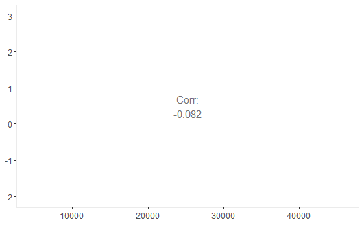

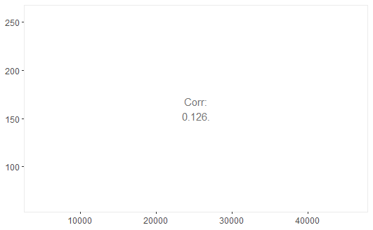

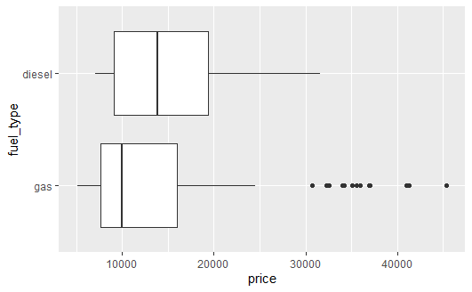

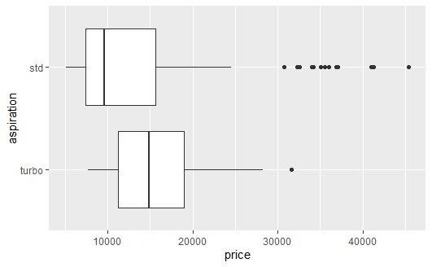

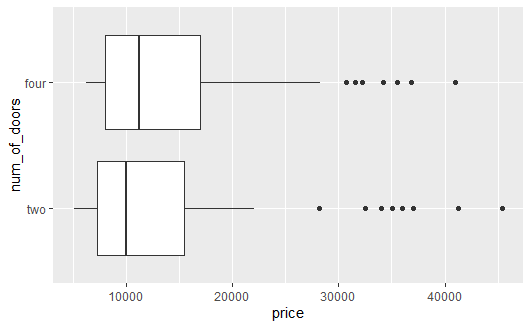

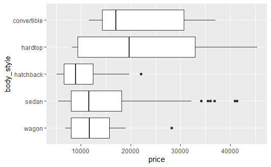

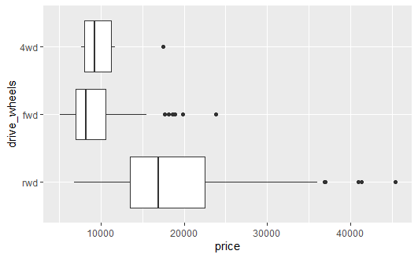

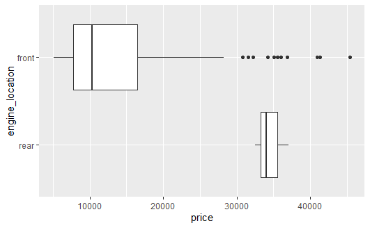

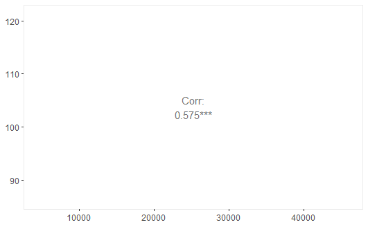

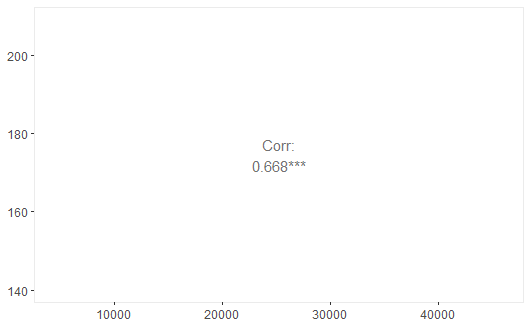

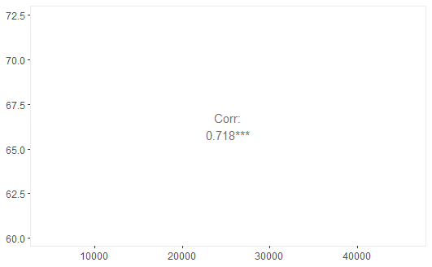

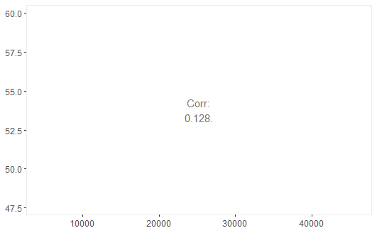

[13 more figures not shown]

```r
a <- tipos_de_graficas(autos_data, todas=FALSE, c("symboling", "normalized_losses", "fuel_type", "aspiration", "num_of_doors", "body_style", "drive_wheels", "engine_location", "wheel_base", "length", "width", "height", "curb_weight", "engine_type", "num_of_cylinders", "engine_size", "fuel_system", "bore", "stroke", "compression_ratio", "horsepower", "peak_rpm", "city_mpg", "highway_mpg", "price"))
for(i in 1:25){
  print(a[i,25] )
}
```

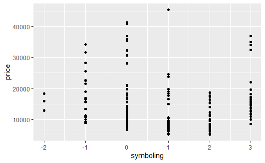

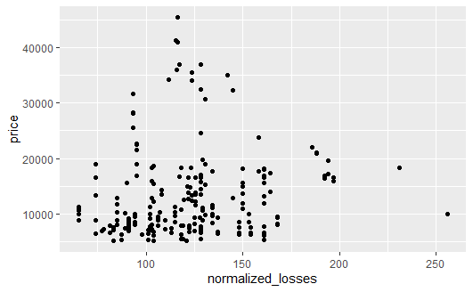

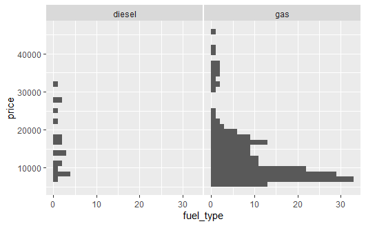

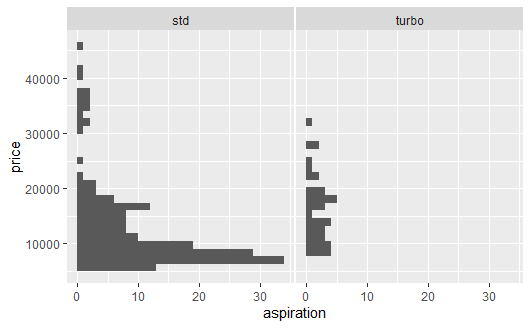

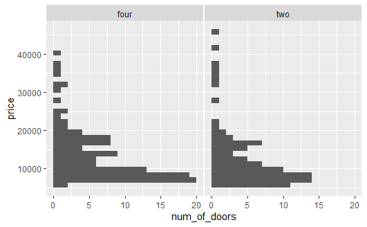

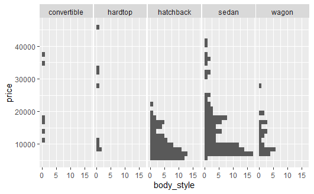

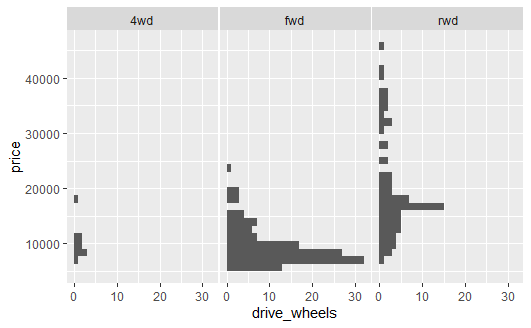

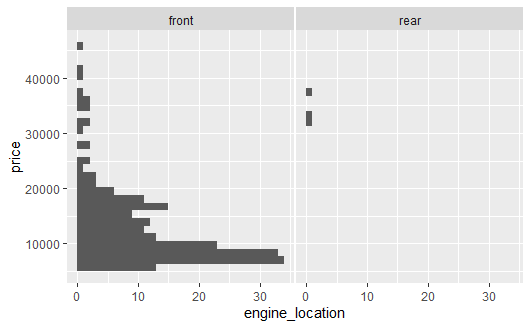

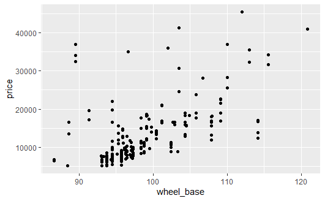

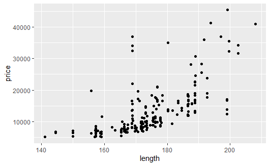

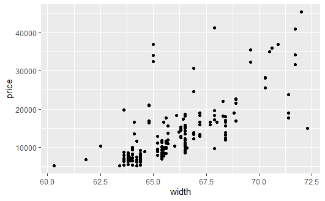

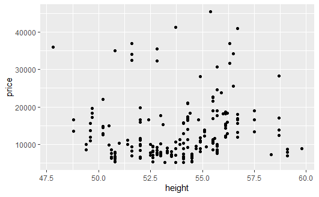

[12 more figures not shown]

```r
for(i in 1:24){
  print(a[25,i])
}
```

#### Podemos ver una correlación positiva entre el precio y wheel-base, horsepower, bore, engine-size, width y length, mientras que tiene una correlación negativa con las variables que tengan mpg, podemos ver que todas las que tienen correlación positiva están afectadas por el tamaño del motor. Mientras que las que tienen una correlación negativa tiene que ver con autos que tienen buen rendimiento de gasolina.

## Análisis Multivariado

```r
ggbiplot(autos.pca)
```

[output not shown]